# Math Scores and Science Scores by Gender

# Introduction

Is there a relationship between a student’s math score and their science score? Is this association the same for female score as it is for male scores? The goal of this analysis was to determine if there was an association between a student’s math score and their science score. Further, this was used to determine if this association was consistent across both genders. The standardized test scores from 200 students were used as data for the analysis.

# Analysis

## Math and Science Association

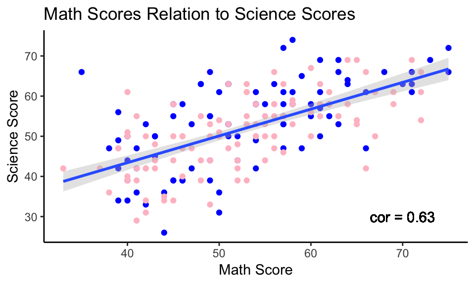

## Math and Science by Gender

This data was then broken down by gender. The same statistical analysis was used to determine if a student’s gender had an impact on the relationship between their math and science grades.

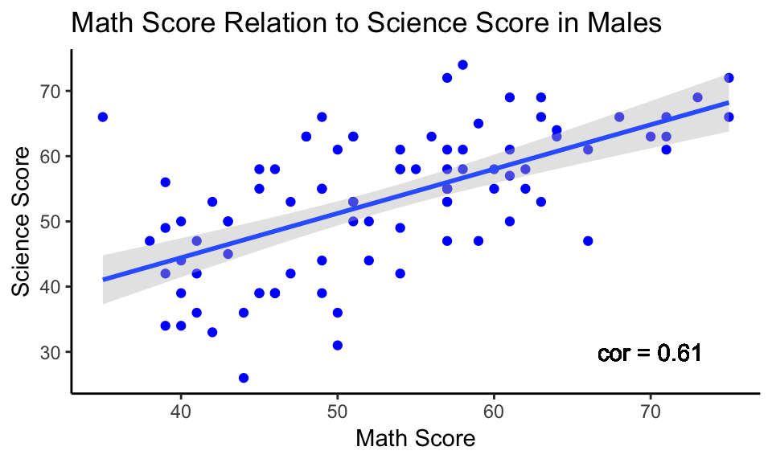

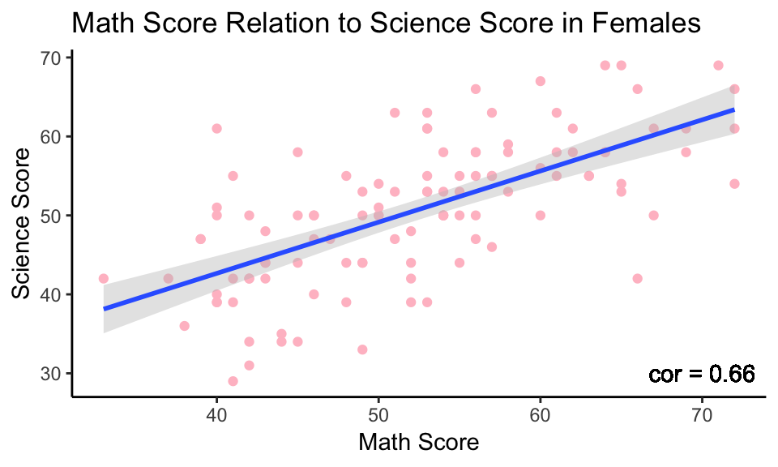

# Conclusion

The correlation coefficient for all students was 0.63. There is a moderately positive correlation between each student’s math and science scores. This means that students who earn high scores in math are likely to earn high scores in science. When the data was broken down by gender, the correlation coefficient for females was 0.66. This was higher than the correlation coefficient for male students, which was 0.61. The analyses provided the 95% confidence intervals for all students in the data set, and for the male and female students separetely. 0.54 < all students < 0.71 & 0.46 < male < 0.73 & 0.53 < female < 0.75.  
The association between math scores and science scores is stronger for female students than for all students in the data and for just the male students.